# Data Science II

Session 4: Spatial Joins, Measurement, and Buffers

Bogdan G. Popescu

bgpopescu@tec.mx

Tec de Monterrey

## What You’ll Learn Today

1. What a spatial function hands back: **predicates**, **measures**, **constructors**
2. **`st_join`** — combining layers by **location** instead of by a shared code
3. **Measures**: `st_area`, `st_centroid`, `st_distance`, `st_nearest_feature` — and why the CRS decides the answer
4. **Constructors**: buffers, unions, intersections, and geometry casting
5. A complete **access-to-services analysis**, end to end

The question we answer today: **how far is each municipio in Yucatán from its nearest hospital?**

## Before We Start

```r
#Step1: Libraries for today
library(sf)
library(dplyr)
library(ggplot2)
library(patchwork)

sf_use_s2(FALSE)
```

Data, as before, in `../data/` — download first if you do not still have them:

- [denue_salud_yucatan.csv](https://www.dropbox.com/scl/fi/dwphvtpr73vb7w6tqfs8m/denue_salud_yucatan.csv?rlkey=ocko0utdvshwgmchffyl4zoez&dl=0) — 6,460 health establishments, into `data/denue/`
- [gadm41_MEX_shp/](https://www.dropbox.com/scl/fo/5jkxbgp29r54zy8ero09h/AL3AFvnq14D4piZ8pQKZRjg?rlkey=6vgggjk5gl4kag50vtyoczn2x&dl=0) — municipio boundaries, the whole folder

## Where We Left Off

In Session 3 we joined homicides to boundaries on **`CVEGEO`** — a shared code present in both tables.

That is an ordinary `left_join`. Nothing spatial happened.

But often there **is** no shared code. You have coordinates on one side and polygons on the other, and the only thing connecting them is **where they are**.

# Part A: Joins — Predicates Plus Bookkeeping

## Join by Location

**The points.** Three real hospitals from DENUE — a name and a place.

```r
demo_hosp <- st_sf(
  hospital = c("Faro del Mayab",
               "Clínica Hospital Mérida",
               "Naval de Yukalpetén"),
  geometry = st_sfc(
    st_point(c(-89.60121, 21.04386)),
    st_point(c(-89.69165, 20.97476)),
    st_point(c(-89.66050, 21.28756))),
  crs = 4326)

demo_hosp
```

```
Simple feature collection with 3 features and 1 field
Geometry type: POINT
Dimension:     XY
Bounding box:  xmin: -89.69165 ymin: 20.97476 xmax: -89.60121 ymax: 21.28756
Geodetic CRS:  WGS 84
                 hospital                   geometry
1          Faro del Mayab POINT (-89.60121 21.04386)
2 Clínica Hospital Mérida POINT (-89.69165 20.97476)
3     Naval de Yukalpetén  POINT (-89.6605 21.28756)
```

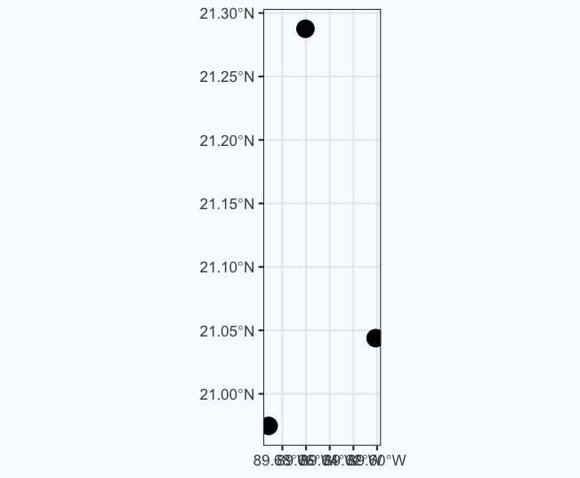

`1 field` — just the hospital’s name. Nothing here says which **municipio** each one is in.

## Join by Location

**The polygons.** Two municipios that share a border.

```r
demo_mun <- st_read("../data/gadm41_MEX_shp/gadm41_MEX_2.shp",
                quiet = TRUE) %>%
  filter(NAME_1 == "Yucatán",
         NAME_2 %in% c("Mérida", "Progreso")) %>%
  select(NAME_2)

demo_mun
```

```
Simple feature collection with 2 features and 1 field
Geometry type: MULTIPOLYGON
Dimension:     XY
Bounding box:  xmin: -89.86554 ymin: 20.69711 xmax: -89.4513 ymax: 21.31777
Geodetic CRS:  WGS 84
    NAME_2                       geometry
1   Mérida MULTIPOLYGON (((-89.58713 2...
2 Progreso MULTIPOLYGON (((-89.51547 2...
```

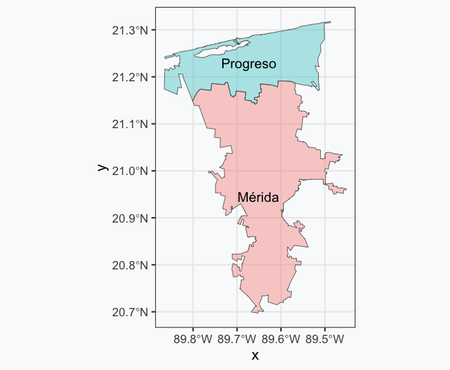

`1 field` each — `NAME_2`. This is the attribute we want to hand to the points.

## Join by Location

**Put them on the same map.**

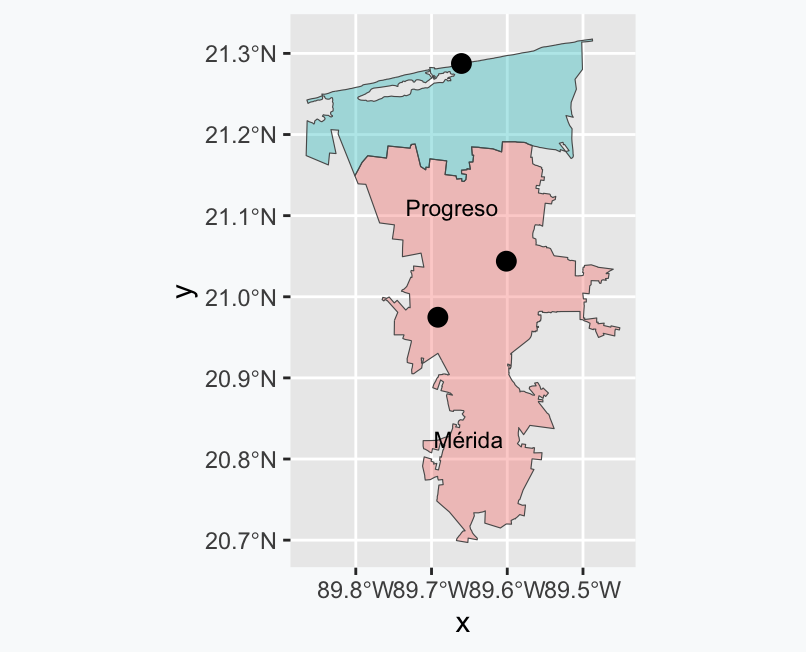

```r
ggplot() +
  geom_sf(data = demo_mun, aes(fill = NAME_2), alpha = 0.35) +
  geom_sf(data = demo_hosp, size = 3) +
  geom_sf_text(data = demo_mun, aes(label = NAME_2), size = 3,
               nudge_y = -0.12) +
  theme(legend.position = "none")
```

**Two** hospitals sit in Mérida, **one** in Progreso. Your eye does the join instantly; `st_join` is how you say it to R.

## Join by Location

**The join.** `NAME_2` crosses from the municipios into the hospitals.

```r
demo_joined <- st_join(demo_hosp, demo_mun, join = st_within)

demo_joined
```

```
Simple feature collection with 3 features and 2 fields
Geometry type: POINT
Dimension:     XY
Bounding box:  xmin: -89.69165 ymin: 20.97476 xmax: -89.60121 ymax: 21.28756
Geodetic CRS:  WGS 84
                 hospital   NAME_2                   geometry
1          Faro del Mayab   Mérida POINT (-89.60121 21.04386)
2 Clínica Hospital Mérida   Mérida POINT (-89.69165 20.97476)
3     Naval de Yukalpetén Progreso  POINT (-89.6605 21.28756)
```

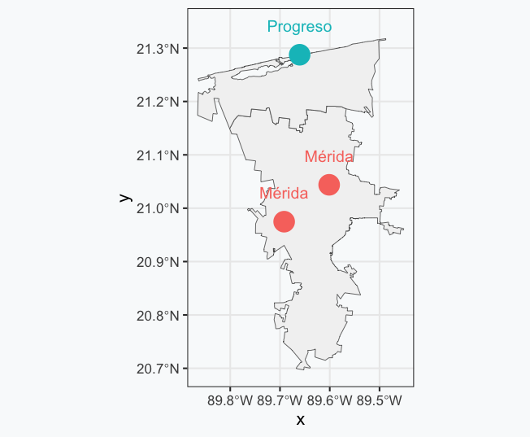

`2 fields`, and **both Mérida hospitals got the same value**. The polygon hands its attribute to *every* point inside it — still three rows, none added, none lost.

## Join by Location

DENUE already carries a `municipio` column, so you can check this answer. **Later today we do exactly that at scale — and find where the two disagree.**

A **spatial join** matches rows from two layers by a **geometric relationship**. Everything today is a variation on this — the difference is that with 6,460 points you *cannot* check by eye.

## The `sf` Operations Toolkit

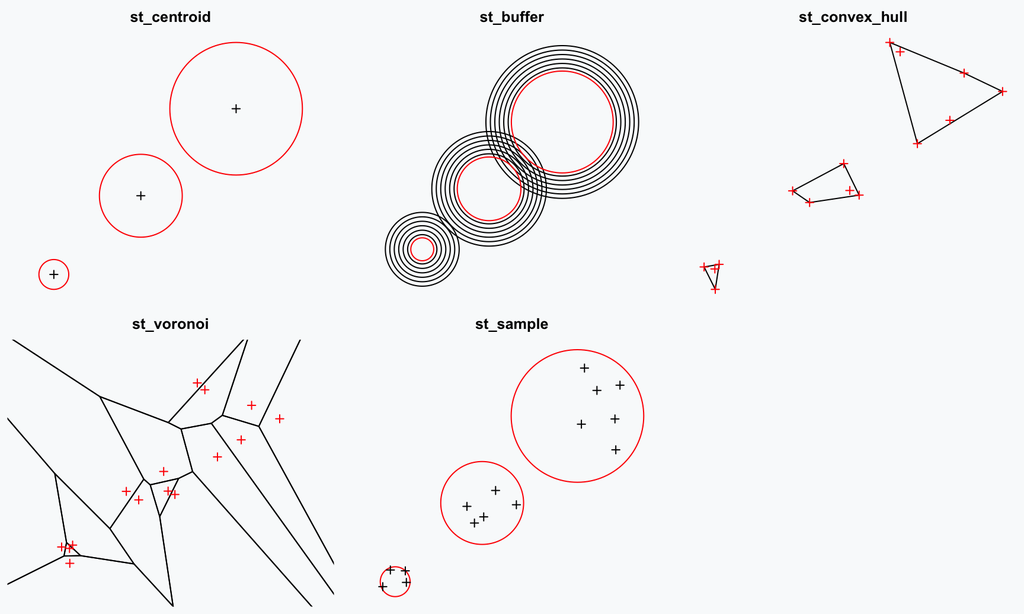

Every panel above was **drawn by the function it names**. They all begin `st_`, they all take `sf` objects, and they all return `sf` objects.

## What a Spatial Function Hands Back

| It returns | The family | Examples | What you do next |
| --- | --- | --- | --- |
| `TRUE`/`FALSE`, or a list of indices | **predicates** | `st_intersects`, `st_within` | filter rows, or drive a join |
| a number | **measures** | `st_area`, `st_distance` | put it in a column |
| a new geometry | **constructors** | `st_buffer`, `st_centroid`, `st_union` | draw it, or feed it back in |
| a table | **joins and filters** | `st_join`, `st_filter` | ordinary `dplyr` from here |

Every panel on the last slide was a **constructor** — geometry in, new geometry out.

A join is a **predicate plus bookkeeping**: `st_join(x, y, join = st_within)` runs the predicate, then attaches columns. That is why the predicate is an *argument*.

This session walks the three families in order: **A** joins, **B** measures, **C** constructors.

## The Setup

```r
#Step1: The points -- health establishments with coordinates
denue   <- read.csv("../data/denue/denue_salud_yucatan.csv")
pts <- st_as_sf(denue, coords = c("longitud", "latitud"), crs = 4326)

#Step2: The polygons -- Yucatán municipios
mex <- st_read("../data/gadm41_MEX_shp/gadm41_MEX_2.shp", quiet = TRUE)
yuc <- mex %>%
  filter(NAME_1 == "Yucatán") %>%
  select(NAME_2)

nrow(pts)
```

```
[1] 6460
```

```r
nrow(yuc)
```

```
[1] 106
```

6,460 points, 106 polygons, and **no shared key** — the DENUE file has a municipio *name*, but we are going to ignore it and use geometry instead.

## The Setup

One more layer for later — just the hospitals:

```r
#Step3: DENUE activity code 6221 is "hospital general"
hospitals <- denue %>%
  filter(substr(as.character(codigo_act), 1, 4) == "6221") %>%
  st_as_sf(coords = c("longitud", "latitud"), crs = 4326)

nrow(hospitals)
```

```
[1] 106
```

**106 hospitals** — one for every municipio in the state, if they were spread evenly. Part B asks whether they are.

## `st_join`

```r
#Step1: attach to each point the polygon it falls inside
joined <- st_join(pts, yuc, join = st_within)

#Step2: every point now carries a NAME_2
joined %>%
  st_drop_geometry() %>%
  filter(nom_estab != "") %>%
  select(nom_estab, NAME_2) %>%
  head(3)
```

```
                        nom_estab NAME_2
1 10 DE MAYO ALCOHOLICOS ANONIMOS  Tecoh
2                 211 GINECOLOGIA Mérida
3                            24/7   Kaua
```

`st_join(x, y)` keeps every row of `x` and adds columns from `y`. It is a **left join**, in spatial clothing.

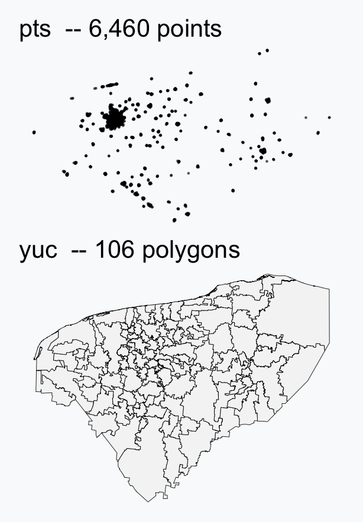

## `st_join`

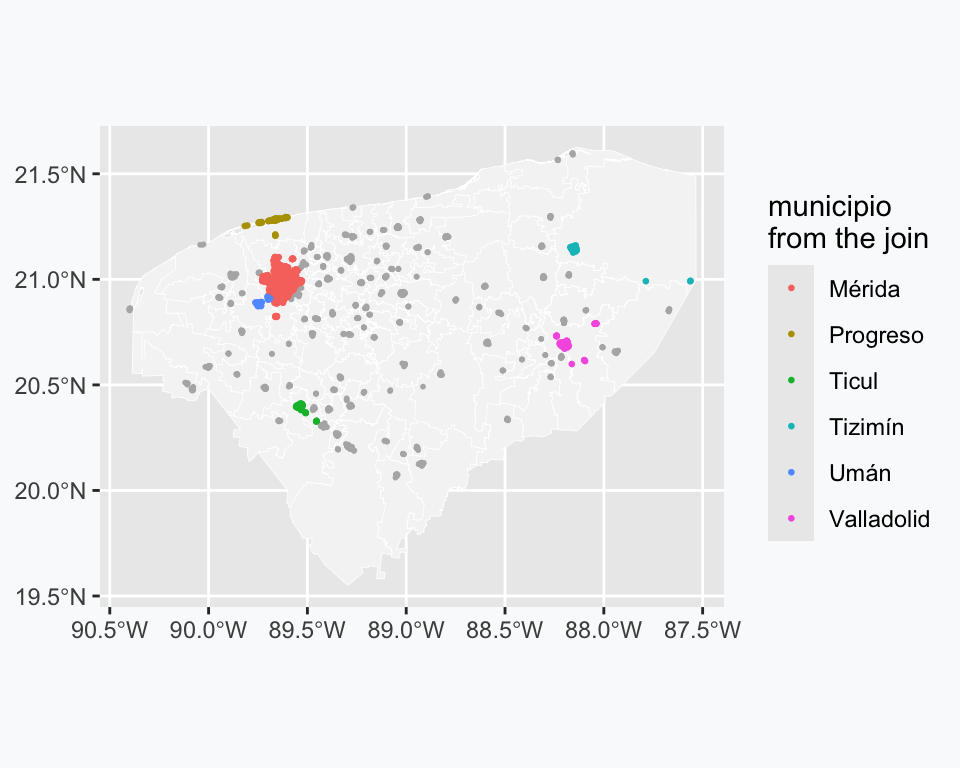

```r
#Step1: the six busiest municipios, by the count the join produced
top6 <- joined %>%
  st_drop_geometry() %>%
  filter(!is.na(NAME_2)) %>%
  count(NAME_2, sort = TRUE) %>%
  slice_head(n = 6) %>%
  pull(NAME_2)

#Step2: name those six, leave the rest grey
ggplot() +
  geom_sf(data = yuc, fill = "grey96",
          colour = "white", linewidth = 0.15) +
  geom_sf(data = filter(joined, !NAME_2 %in% top6),
          colour = "grey70", size = 0.35) +
  geom_sf(data = filter(joined, NAME_2 %in% top6),
          aes(colour = NAME_2), size = 0.5) +
  labs(colour = "municipio\nfrom the join")
```

## Counting Points per Polygon

```r
#Step1: Drop the geometry and count -- ordinary dplyr from here
spatial_count <- joined %>%
  st_drop_geometry() %>%
  filter(!is.na(NAME_2)) %>%
  count(NAME_2, name = "spatial")

head(spatial_count, 4)
```

```
   NAME_2 spatial
1   Abalá       5
2 Acanceh      19
3    Akil      32
4    Baca      22
```

## Counting Points per Polygon

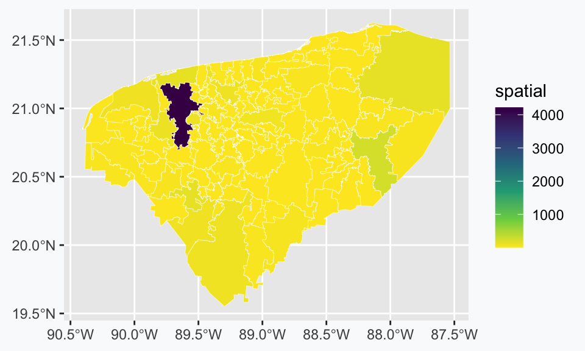

```r
yuc %>%
  left_join(spatial_count, by = "NAME_2") %>%
  ggplot() +
  geom_sf(aes(fill = spatial), colour = "white", linewidth = 0.1) +
  scale_fill_viridis_c(direction = -1)
```

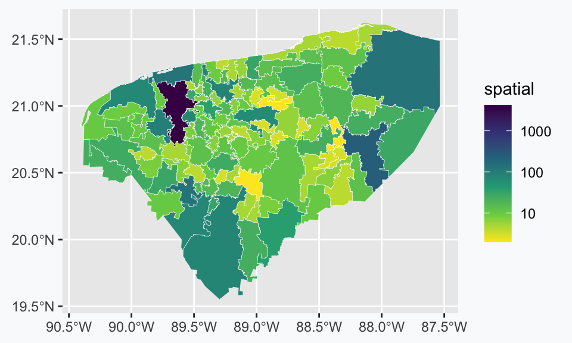

```r
#The same map on a log scale
yuc %>%
  left_join(spatial_count, by = "NAME_2") %>%
  ggplot() +
  geom_sf(aes(fill = spatial), colour = "white", linewidth = 0.1) +
  scale_fill_viridis_c(direction = -1, trans = "log10")
```

Same data, same join. On the **linear** scale Mérida’s 4,218 swamps everything; on the **log** scale you can finally see the other 105 municipios differ from one another.

## Counting Points per Polygon

Zoom in, and the colour is just a number you can read off the map.

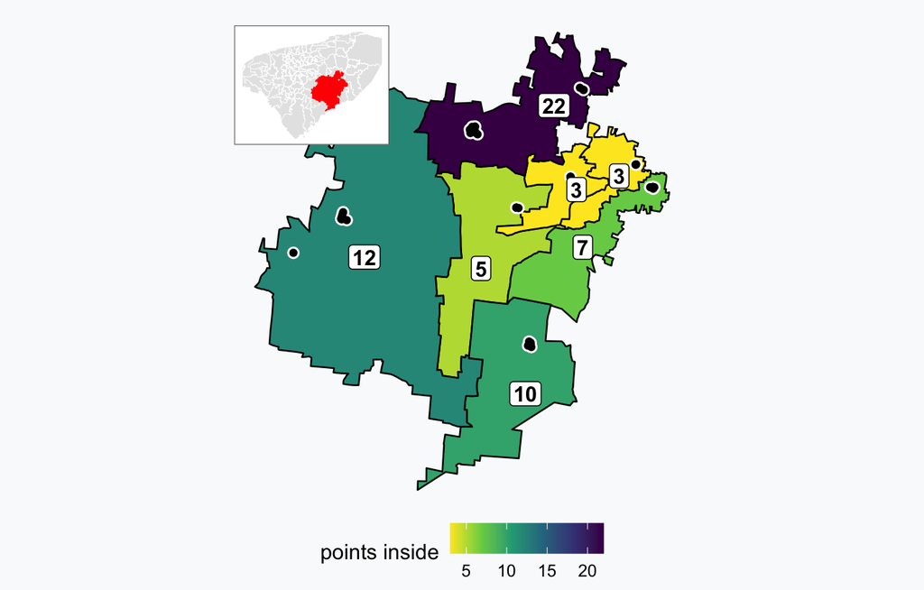

The inset shows where we are — central Yucatán, east of Mérida. Seven municipios, the black dots are the establishments, and the number on each is exactly how many fell inside it. **Tinum 22, Yaxcabá 12, Chankom 5, Kaua 3** — darker means more, and the label proves it.

## Why They Disagree

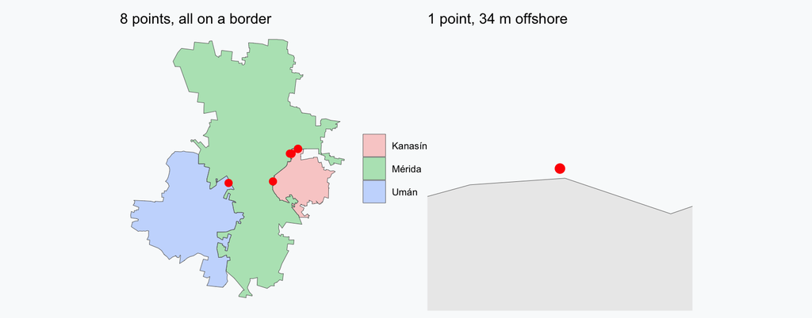

**Seven** establishments DENUE labels *Kanasín* have coordinates inside *Mérida*; **one** labelled *Mérida* falls in *Umán*. Every one sits on the metropolitan boundary — where an address and a GPS reading are most likely to part company.

The last is a coastal clinic in **San Felipe**, sitting **34 m** outside GADM’s simplified shoreline. The clinic is real; the coastline is approximate.

## Which Answer Do You Trust?

DENUE carries a municipio **label**. The join just produced one from **geometry**. Do they agree?

```r
#Step1: points whose label disagrees with where they fell
joined %>%
  st_drop_geometry() %>%
  filter(!is.na(NAME_2), municipio != NAME_2) %>%
  nrow()
```

```
[1] 8
```

```r
#Step2: points that fell outside every polygon
sum(is.na(joined$NAME_2))
```

```
[1] 1
```

Eight disagree, one lands nowhere. Neither answer is simply “right”: the **label** is the administrative address a registry recorded; the **geometry** is where a GPS reading fell, judged against a boundary file that is itself simplified.

**Important**

Report the discrepancy rather than hiding it. Nine points out of 6,460 is **0.14%** and changes nothing — if it had been 8%, your whole analysis would rest on which boundary file you happened to download.

## Your Turn: Does the Predicate Matter?

You joined with `st_within`. Try `st_intersects` instead. **Does the answer change? Should it?**

```r
joined_intersects <- st_join(pts, yuc, join = st_intersects)

#Compare: same number of rows? same number of NAs?
nrow(joined_intersects)
```

```
[1] 6460
```

```r
sum(is.na(joined_intersects$NAME_2))
```

```
[1] 1
```

**Identical** — 6,460 rows, 1 unmatched, either way.

**Tip**

The two differ only for a point lying *exactly* on a boundary. None do here. The predicate is a real choice, but not every real choice changes the answer — check rather than assume.

# Part B: Measures — Geometry Returns a Number

## Three Kinds of Calculation

- **Numeric** — returns a number: `st_area`, `st_distance`, `st_length`
- **Logical** — returns TRUE/FALSE: `st_intersects`, `st_within`, `st_disjoint`
- **Spatial** — returns new geometry: `st_centroid`, `st_buffer`, `st_union`

All three need a **projected CRS** if you want answers in metres.

## `st_area`

```r
#Step1: Project first -- EPSG:6372 has units of metres
yuc_p <- st_transform(yuc, 6372)

#Step2: Area comes back with units attached
head(st_area(yuc_p), 3)
```

```
Units: [m^2]
[1] 290237841 136063311  75871595
```

```r
#Step3: Convert to km2 and strip the units for plotting
yuc_p$area_km2 <- as.numeric(units::set_units(st_area(yuc_p), km^2))
round(sum(yuc_p$area_km2))
```

```
[1] 39102
```

39,102 km² — the published area of Yucatán is about 39,600. The 1% gap is boundary simplification.

## `st_area`

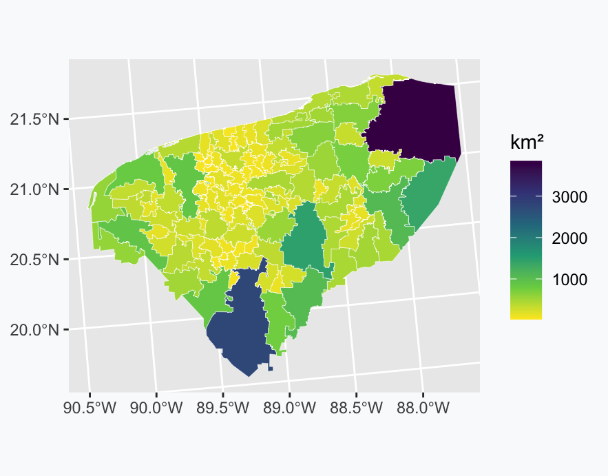

```r
#The column is now ordinary -- map it like any other
ggplot(yuc_p) +
  geom_sf(aes(fill = area_km2),
          colour = "white", linewidth = 0.1) +
  scale_fill_viridis_c(direction = -1,
                       name = "km²")
```

**Tizimín 3,847 km² against Sanahcat 26 km²** — a 148-fold spread. Municipios are nothing like equal-sized, which is why a *count* per municipio told you so little.

## `st_area`: Degrees or Metres?

```r
#Step1: strip the CRS -- st_area just multiplies degrees together
yuc_deg <- st_set_crs(yuc, NA)
head(st_area(yuc_deg), 2)
```

```
[1] 0.02536948 0.01190959
```

```r
#Step2: with a projected CRS, the units come attached
head(st_area(yuc_p), 2)
```

```
Units: [m^2]
[1] 290237841 136063311
```

## `st_area`: Degrees or Metres?

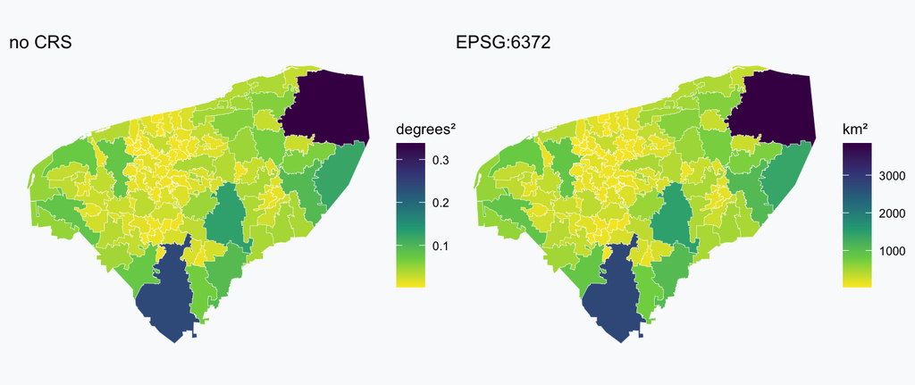

**The same map twice.** The two columns correlate at 1.00 — nothing about the picture tells you one of them is measured in a unit that means different things at different latitudes.

**Warning**

Only the **legend** gives it away. Project before you measure, and keep the `units` that `sf` hands you.

## Your Turn: How Much Does the CRS Cost You?

Yucatán is **39,102 km²** in EPSG:6372. Here are the same polygons measured two ways:

```r
#The state outline, dissolved from the 106 municipios
state <- st_union(yuc_p)

area_lcc      <- st_area(st_transform(state, 6372))
area_mercator <- st_area(st_transform(state, 3857))
```

**By what percentage is the area over- or under-calculated in Web Mercator?**

## `st_centroid`

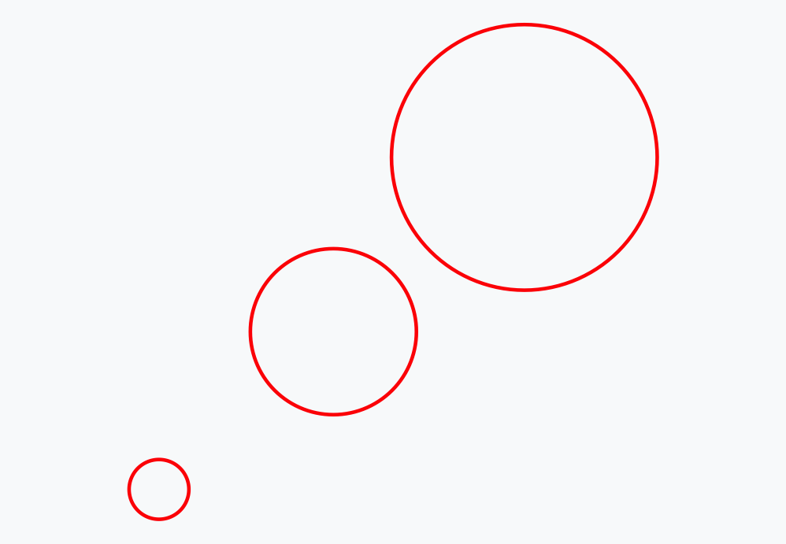

## `st_centroid`

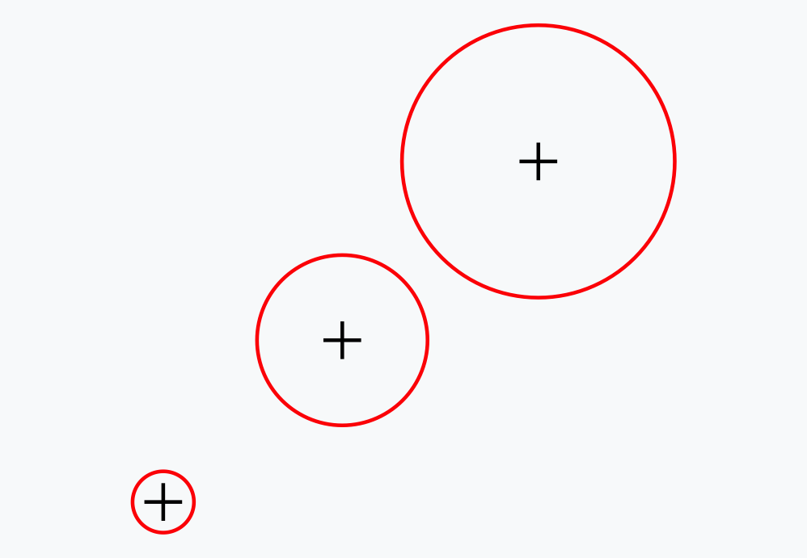

## `st_centroid`

```r
#Step1: one point per polygon
centroids <- st_centroid(yuc_p)
nrow(centroids)
```

```
[1] 106
```

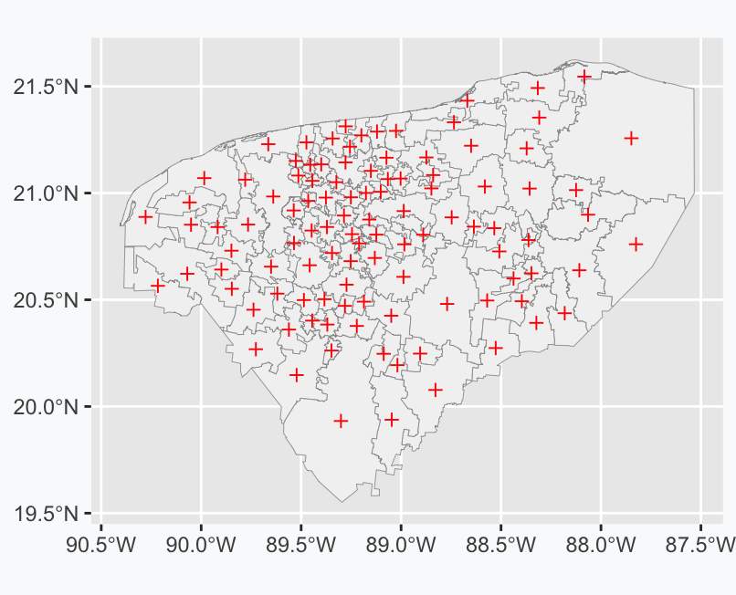

```r
#Step2: polygons underneath, centroids on top
ggplot() +
  geom_sf(data = yuc_p, fill = "grey95",
          colour = "grey60", linewidth = 0.15) +
  geom_sf(data = centroids, shape = 3,
          size = 1.6, colour = "red") +
  coord_sf(crs = 4326)
```

The geometric centre of mass — the same operation as the top-left panel of the toolkit, on real municipios.

## Centroids Can Lie

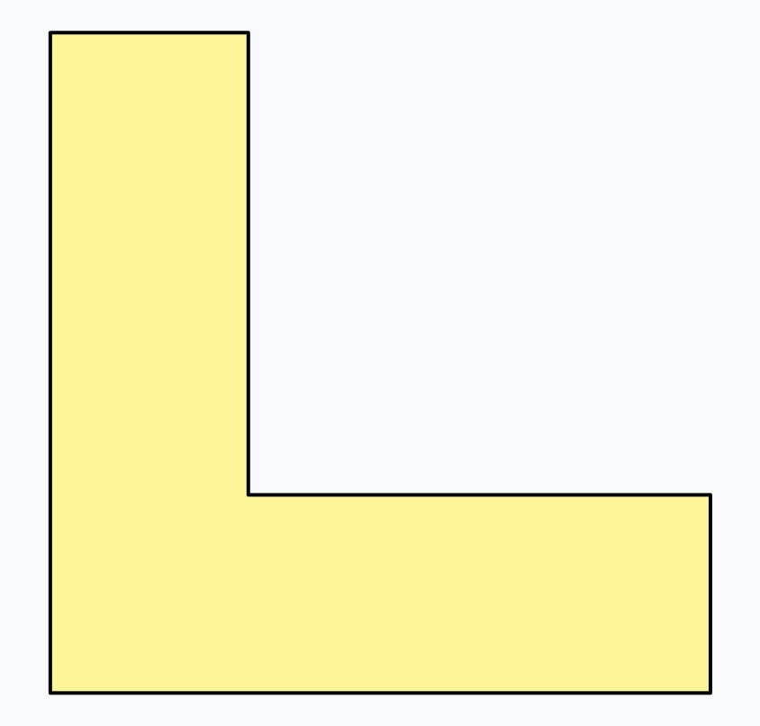

An L-shaped municipio.

## Centroids Can Lie

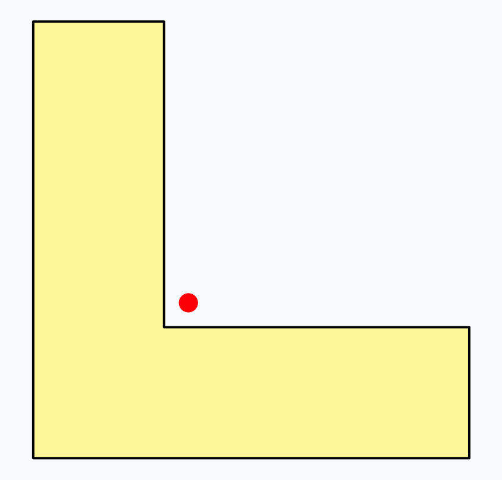

`st_centroid()` — the centre of mass falls **outside** the polygon.

## Centroids Can Lie

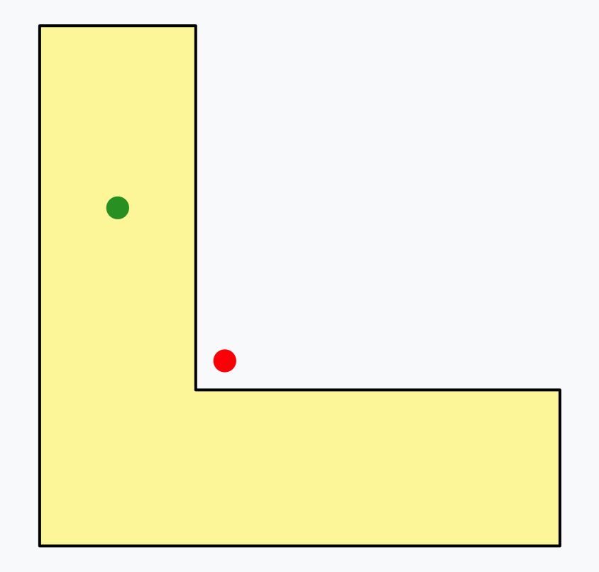

`st_point_on_surface()` — guaranteed to fall **inside**.

## When That Matters

Metlatónoc, Guerrero — **one** polygon with a deep notch. Its centre of mass lands **5.6 km outside** the municipio it belongs to.

Tecomán, Colima is worse: five separate parts, centroid **100.7 km** from any of them.

**Tip**

Not compact, or made of several pieces? Use **`st_point_on_surface()`**.

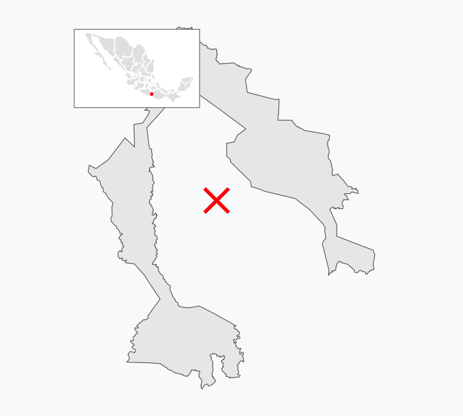

## `st_distance`: Every Centroid to the Capital

```r
#Step1: one target -- Mérida
cap <- centroids %>%
  filter(NAME_2 == "Mérida")

#Step2: many-to-one is a 106 x 1 matrix,
#       which is just a column
yuc_p$km_cap <- as.numeric(
  st_distance(centroids, cap)) / 1000

round(range(yuc_p$km_cap), 1)
```

```
[1]   0.0 189.6
```

**Chemax at 190 km** is the far end. The **0.0** is Mérida measuring itself — the nearest real neighbour is **Kanasín, 13 km**. Median across the state: **67 km**.

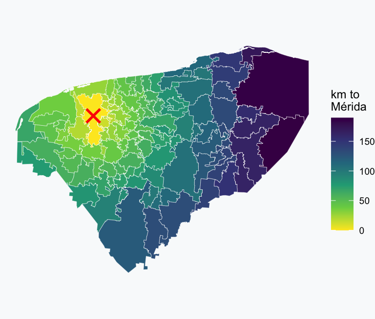

## `st_nearest_feature`

```r
#Step1: The hospitals, projected to match the centroids
hosp <- hospitals %>%
  st_transform(6372)

#Step2: For each centroid, the index of the closest hospital
nearest <- st_nearest_feature(centroids, hosp)
head(nearest)
```

```
[1]  97  35  62  53  72 102
```

```r
#Step3: by_element gives a vector, not a matrix -- one distance per pair
centroids$km_to_hospital <- as.numeric(
  st_distance(centroids, hosp[nearest, ], by_element = TRUE)) / 1000
```

Between **0.5 km** and **44.2 km** to the nearest hospital.

## `st_nearest_feature`

Each line joins a municipio centroid (red **+**) to the hospital it matched (white circle).

Look at the **fans**: one hospital is nearest for five or six municipios at once. The match is **many-to-one**.

Only **57 of the 106 hospitals** are nearest to anything. The other 49 never win.

The longest line is **Chikindzonot, 44.2 km** — and that is straight-line, not by road.

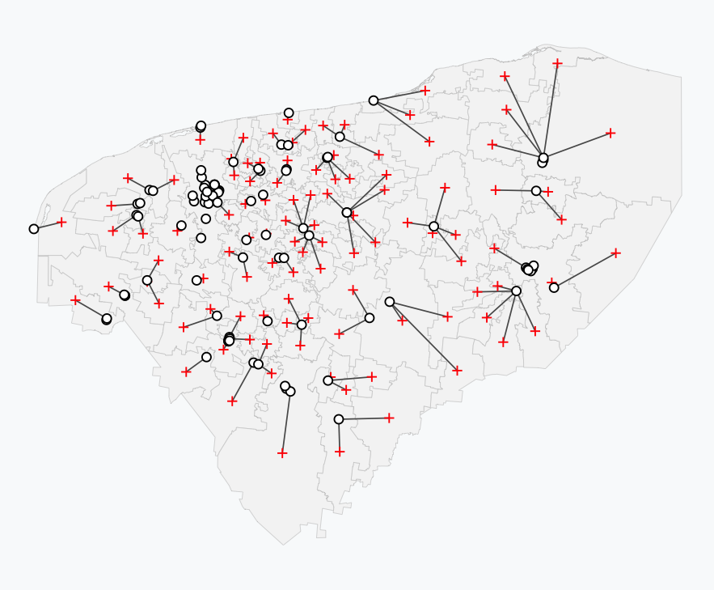

## Who Is Furthest?

```r
centroids %>%
  st_drop_geometry() %>%
  arrange(desc(km_to_hospital)) %>%
  transmute(NAME_2, km = round(km_to_hospital, 1)) %>%
  head(6)
```

```
        NAME_2   km
1 Chikindzonot 44.2
2 Río Lagartos 43.5
3   San Felipe 41.2
4      Tizimín 32.7
5       Chemax 32.5
6     Buctzotz 31.7
```

Chikindzonot, Río Lagartos, San Felipe — the eastern interior and the north coast.

## Mapping Accessibility

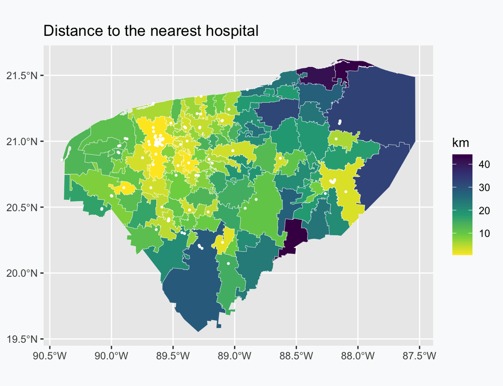

```r
#Step1: Put the distance back on the polygons
yuc_p$km_to_hospital <- centroids$km_to_hospital

#Step2: Map it, hospitals on top
ggplot() +
  geom_sf(data = yuc_p,
          aes(fill = km_to_hospital),
          colour = "white",
          linewidth = 0.1) +
  geom_sf(data = hosp, size = 0.5,
          colour = "white") +
  scale_fill_viridis_c(direction = -1,
                       name = "km") +
  coord_sf(crs = 4326) +
  labs(title = "Distance to the nearest hospital")
```

## Your Turn: Centroid, or a Point Inside?

Part B measured accessibility from `st_centroid`. **Redo it with `st_point_on_surface` — does the worst-served municipio change?**

```r
inside_points <- st_point_on_surface(yuc_p)

km_from_inside <- st_distance(inside_points, hosp[st_nearest_feature(inside_points, hosp), ],
                  by_element = TRUE)

yuc_p$NAME_2[which.max(km_from_inside)]
```

Still **Chikindzonot** — but 46.4 km instead of 44.2, and the **top five change order**.

**Tip**

The headline name survived; the ranking did not. If you were funding the three worst-served municipios, this choice would pick different ones.

# Part C: Constructors — Geometry In, New Geometry Out

## Buffers

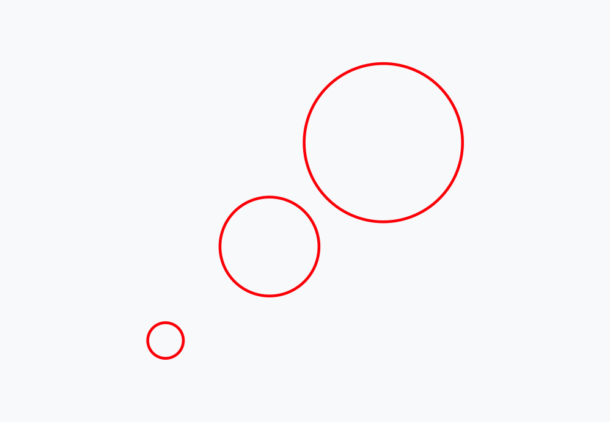

## Buffers

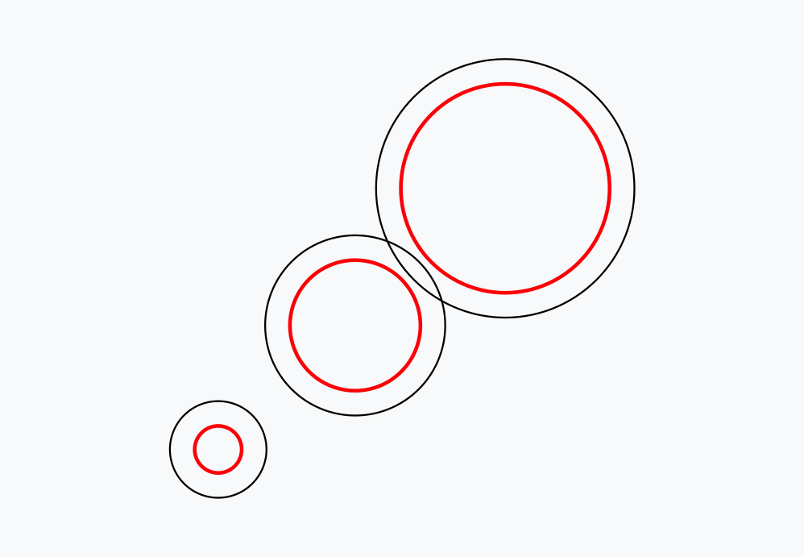

## Buffers

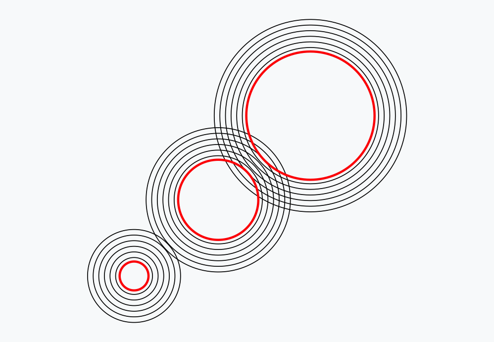

`st_buffer(x, dist)` grows a geometry outward by `dist` — turning a point into a circle, a line into a corridor, a polygon into a larger polygon.

## Buffers Need Metres

```r
#Step1: The layer is already in EPSG:6372, so dist is in METRES
buf10 <- st_buffer(hosp, 10000)   # 10 km
nrow(buf10)
```

```
[1] 106
```

**Warning**

The number you pass to `dist` is in the **units of the layer’s CRS**. In EPSG:6372 that is metres, so `10000` is 10 km. In EPSG:4326 it would be **10,000 degrees** — twenty-seven times around the planet.

Modern `sf` will quietly do the geodesically correct thing on a geographic CRS, which is worse in a way: you get a plausible answer without ever learning you were sloppy.

## `st_union`: Dissolving

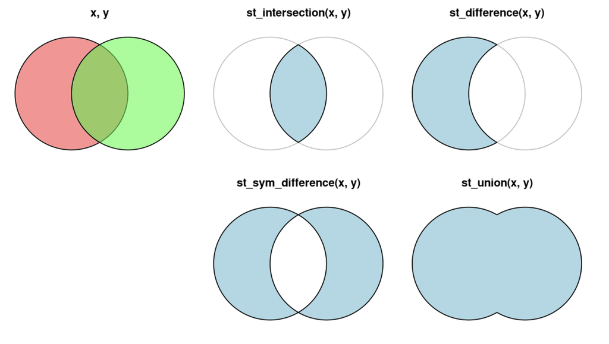

```r
#Step1: 106 overlapping circles become one multipolygon
buffers_merged <- st_union(buf10)
length(buffers_merged)
```

```
[1] 1
```

Without the union, overlapping buffers would double-count the area they share.

## `st_intersection`

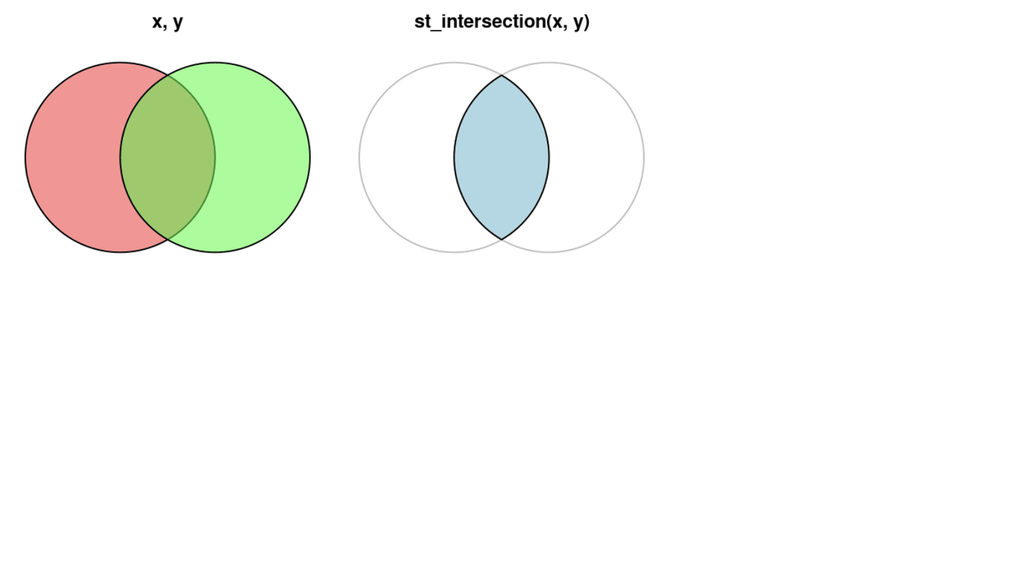

```r
#Step1: Clip the coverage to the state -- circles spill into the sea
state    <- st_union(yuc_p)
coverage <- st_intersection(state, buffers_merged)
```

## `st_difference`

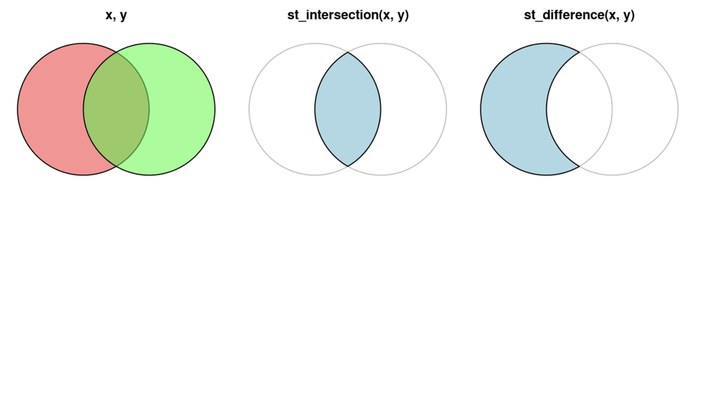

```r
#Step1: The complement -- everywhere NOT within 10 km of a hospital
gap <- st_difference(state, buffers_merged)
```

`intersection` is “in both”, `difference` is “in the first but not the second”, `union` is “in either”. Those three cover most overlay work.

## How Much of the State Is Covered?

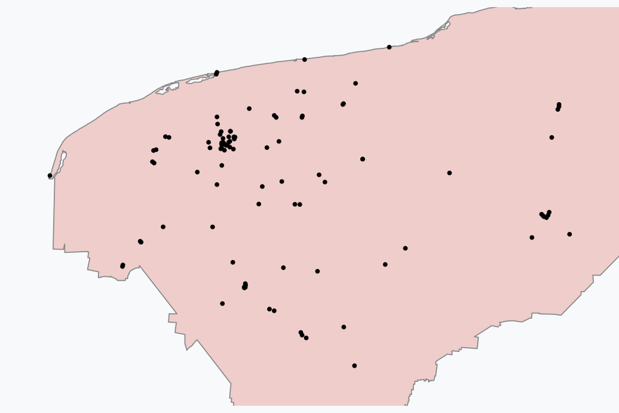

```r
#--- built on earlier slides ---
hospitals <- denue %>%
  filter(substr(as.character(codigo_act), 1, 4) == "6221") %>%
  st_as_sf(coords = c("longitud", "latitud"), crs = 4326)

hosp <- hospitals %>%
  st_transform(6372)

state <- st_union(yuc_p)
buf10 <- st_buffer(hosp, 10000)          # 10 km

bb <- st_bbox(st_transform(buf10, 4326))

ggplot() +
  geom_sf(data = state, fill = "#f2d7d5", colour = "grey60", linewidth = 0.3) +
  geom_sf(data = hosp, size = 0.7, colour = "black") +
  coord_sf(xlim = bb[c("xmin", "xmax")],
           ylim = bb[c("ymin", "ymax")], crs = 4326) +
  theme_void()
```

Start with the **106 hospitals**.

## How Much of the State Is Covered?

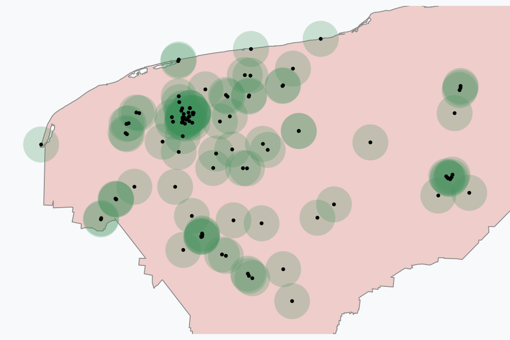

```r
#--- built on earlier slides ---
hospitals <- denue %>%
  filter(substr(as.character(codigo_act), 1, 4) == "6221") %>%
  st_as_sf(coords = c("longitud", "latitud"), crs = 4326)

hosp <- hospitals %>%
  st_transform(6372)

state <- st_union(yuc_p)
buf10 <- st_buffer(hosp, 10000)          # 10 km

bb <- st_bbox(st_transform(buf10, 4326))

ggplot() +
  geom_sf(data = state, fill = "#f2d7d5", colour = "grey60", linewidth = 0.3) +
  geom_sf(data = buf10, fill = "#4c9f70", colour = NA, alpha = 0.25) +
  geom_sf(data = hosp, size = 0.7, colour = "black") +
  coord_sf(xlim = bb[c("xmin", "xmax")],
           ylim = bb[c("ymin", "ymax")], crs = 4326) +
  theme_void()
```

`st_buffer(hosp, 10000)` draws a **10 km circle** around each one. They overlap each other, and some spill into the sea.